# RNA-seq and metabolomics on EHEC infection model

Diogo M. Camacho  
Alessio Tovaglieri

May 30, 2018

# Experimental data

- Multi-omics data collected for Human Gut-Chip
- Multiple conditions

# Transcriptomics

1. Mapping data to EHEC
   - used `KEGGREST` package in `R` to map IDs to genes
2. Filtering
   - removed genes with 0 read counts across *all* experiments

This resulted in 5281 genes for further analyses.

# How good are the samples?

Based on Pearson correlation, are replicates “replicating”?

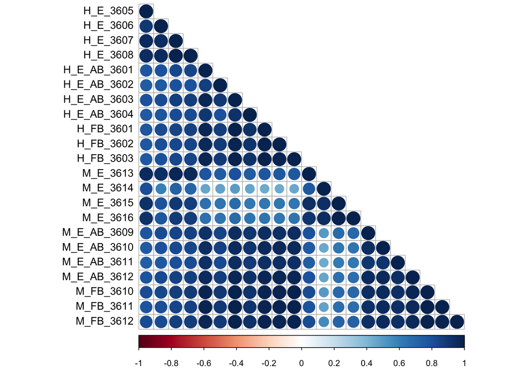

# t-SNE plots on samples

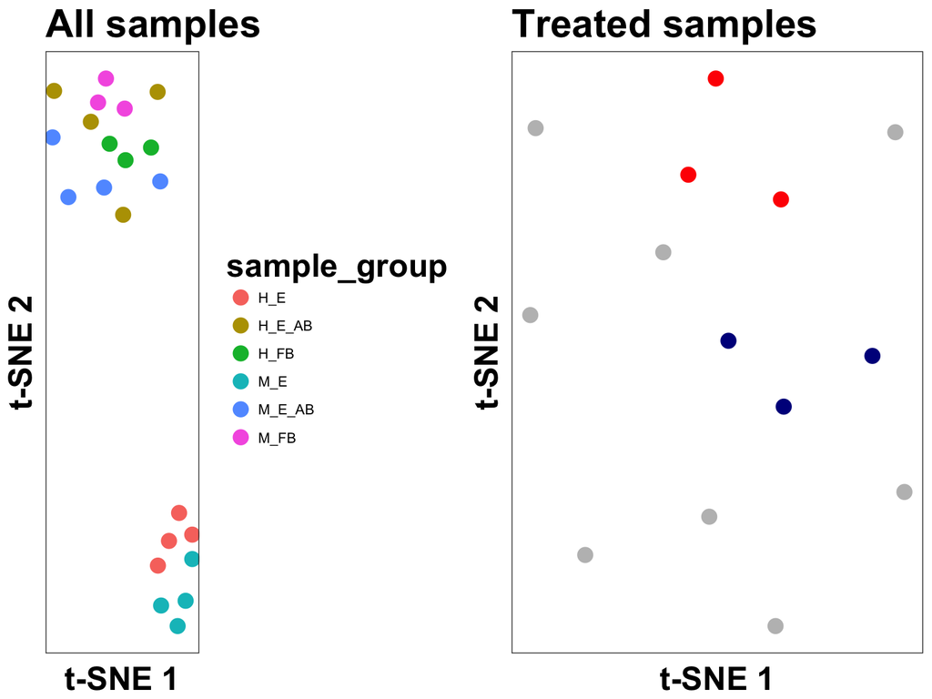

# Differential expression analyses

- Ran `DESeq2` to compute differential expression of floating bacteria, in human microbial metabolites versus murine microbial metabolites;
- Identified 898 differentially expressed (q < 0.05), split between 50 up-regulated genes and 295 down-regulated genes (fold change > 2).

# Pathway enrichment on differentially expressed genes

- Thresholded genes based on FDR q-value only;
- Enrichment ran against: GO Biological Process gene sets (K12 gene sets), KEGG pathway gene sets (EHEC specific), KEGG module gene sets (EHEC specific)

# Pathway enrichments: GO terms

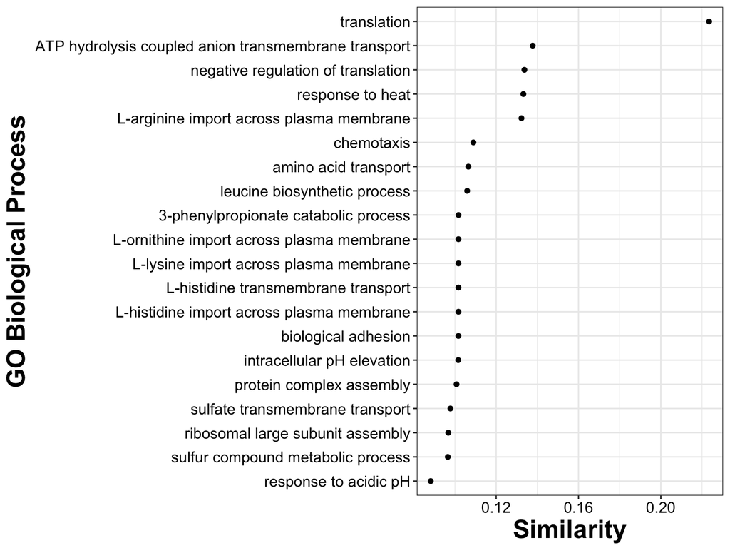

# Pathway enrichments: KEGG pathways

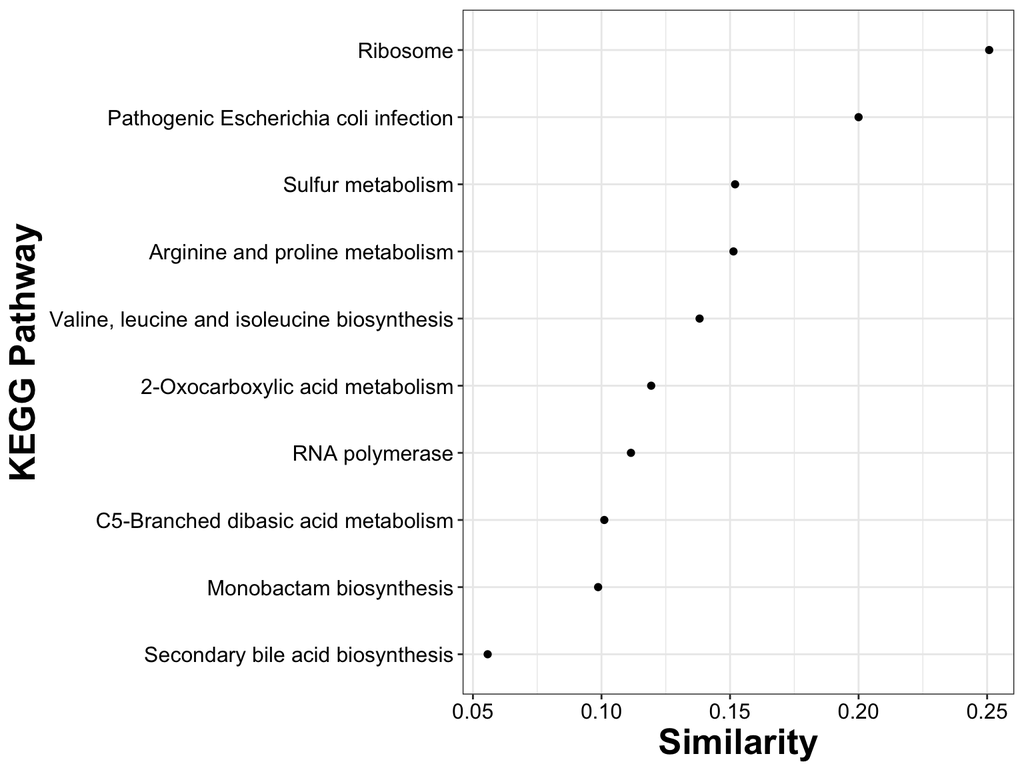

# Pathway enrichments: KEGG modules

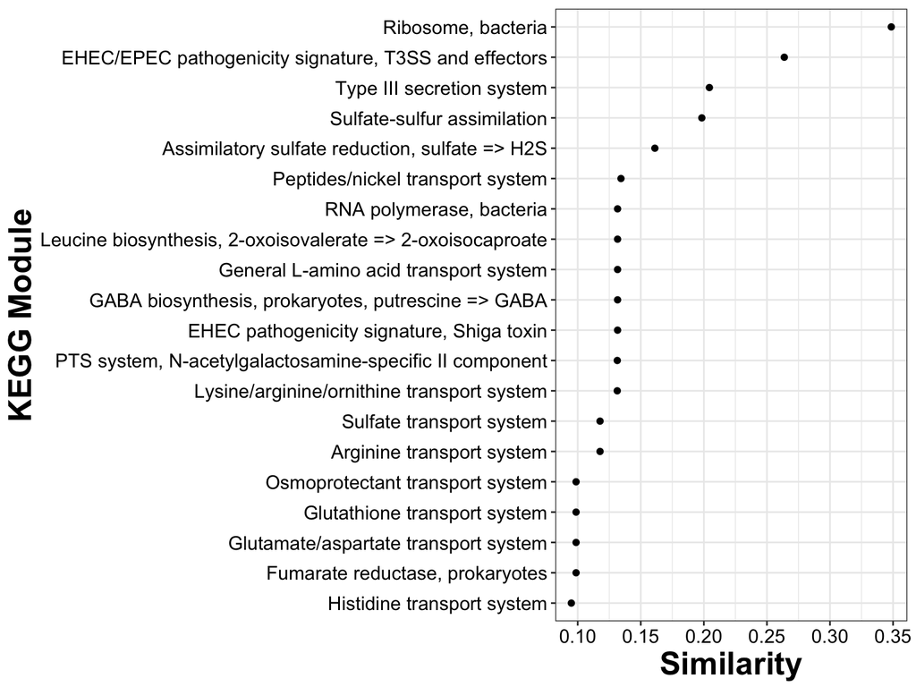

# Gene set specific heatmaps: Chemotaxis

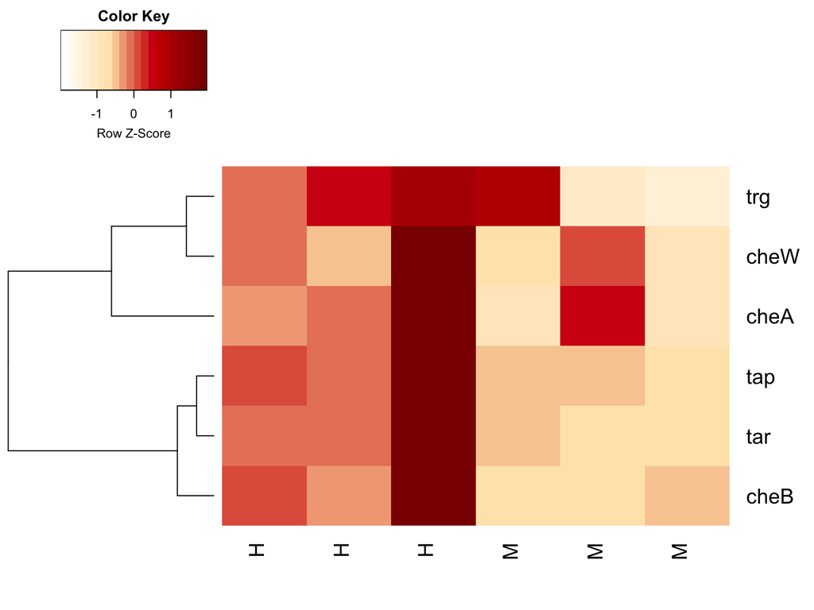

# Gene set specific heatmaps: KEGG module Pathogenic E. coli infection

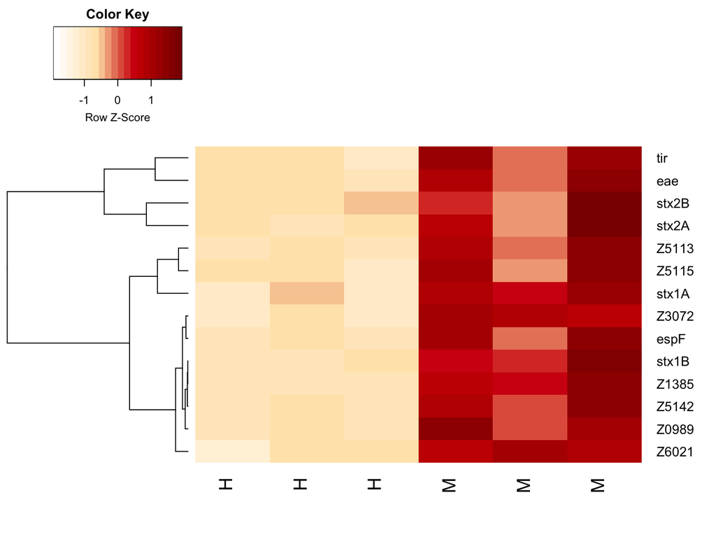

# Gene set specific heatmaps: KEGG module Type III secretion system

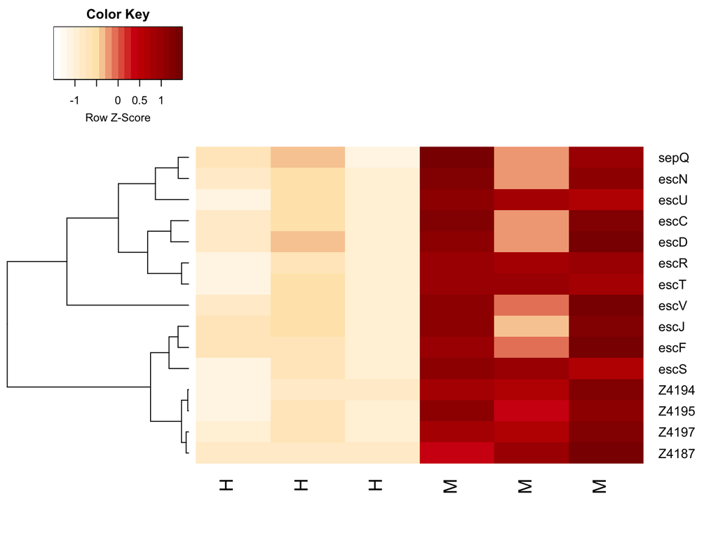

# Enrichment of up or down regulated independently

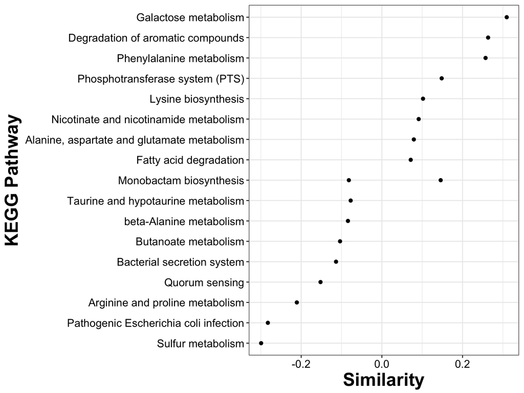

# Gene set for top up and down regulated KEGG pathway

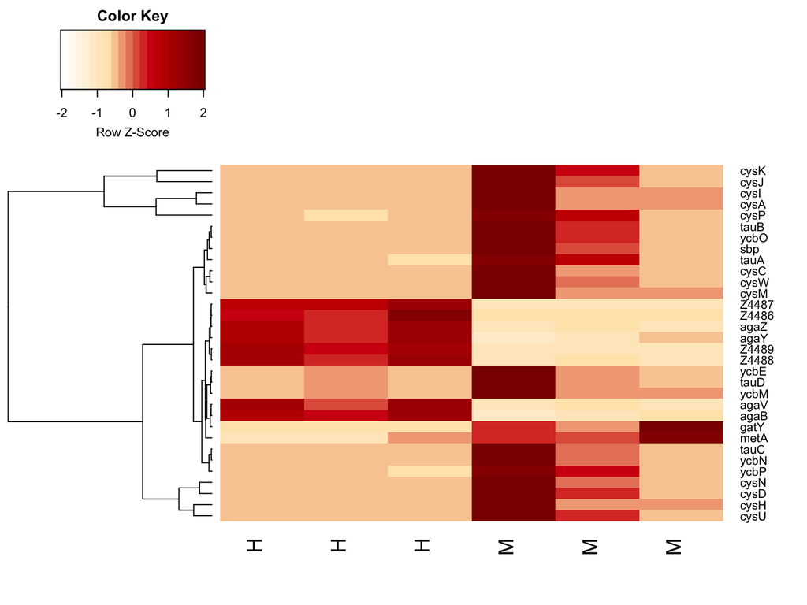

# KEGG Modules add aditional layer of biological understanding

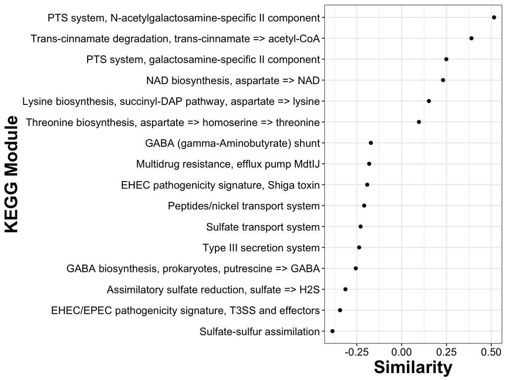

# Intermission

- Gene expression signatures for EHEC in contact with mouse microbial or human microbial metabolites may give hint into tolerance mechanism

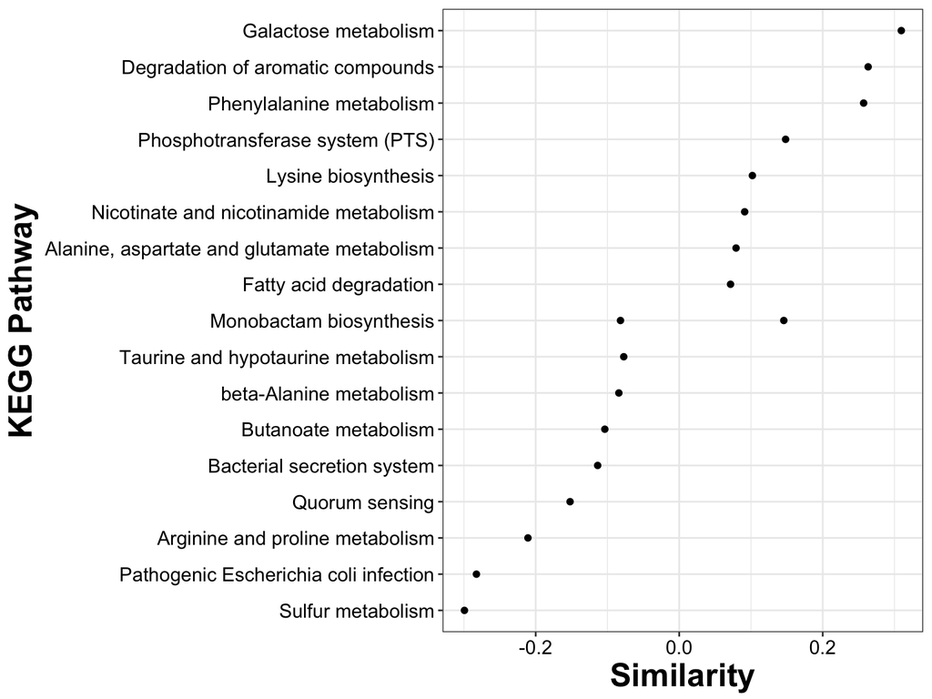

# Metabolomics data

- Normalized intensities using a quantile normalization (similar to RMA normalization)

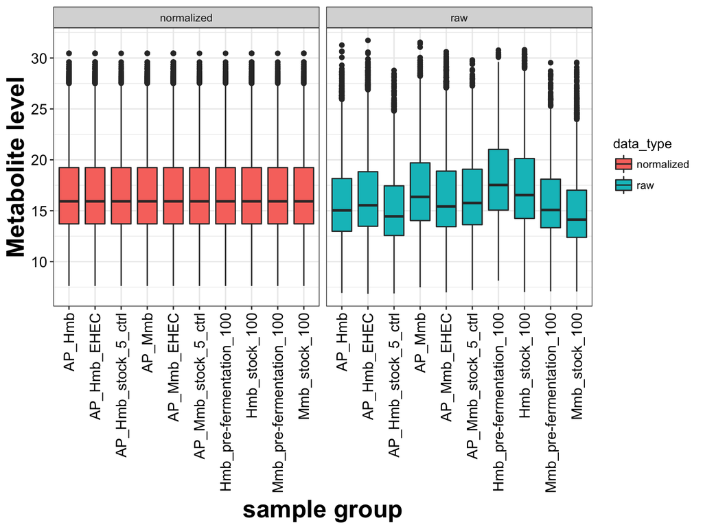

# How good are these replicates?

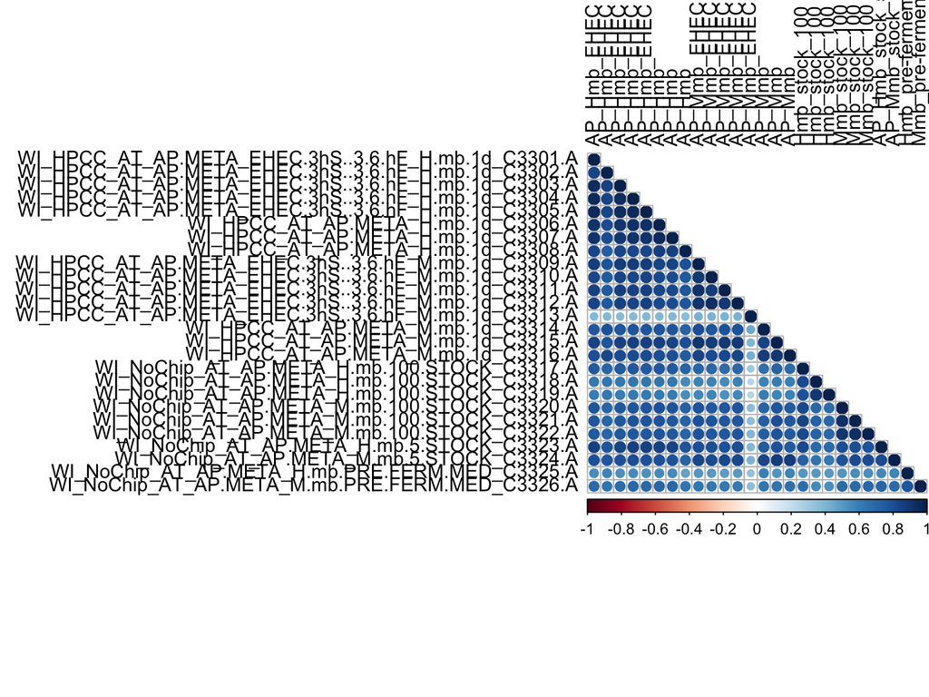

- Sample 3313A is not well correlated with its replicate counterparts. We will discard this sample.

# Subsetting metabolites

- We will only include metabolites that *increase* their abundance between pre-fermentation state and after microbial metabolites (human or murine) are added.
  - rationale: these are the metabolites that are *produced* by either the host or the microbiome that will have significance for phenotype

# Subseting metabolites: heatmap

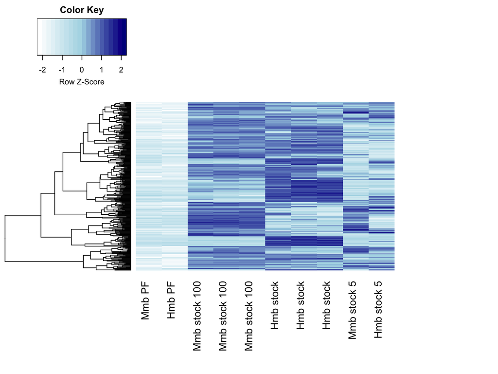

Found a total of 329 metabolites that increase abundance when exposed to *either* microbiome.

# How metabolites change

- Comparisons to make:
  - infection effects:
    - mouse mm + ehec / mouse mm
    - human mm + ehec / human mm
  - epithelial cells effect:
    - mouse mm / mouse mm stock 5
    - human mm / human mm stock 5

# Infection metabolites

# Mouse metabolites in infection

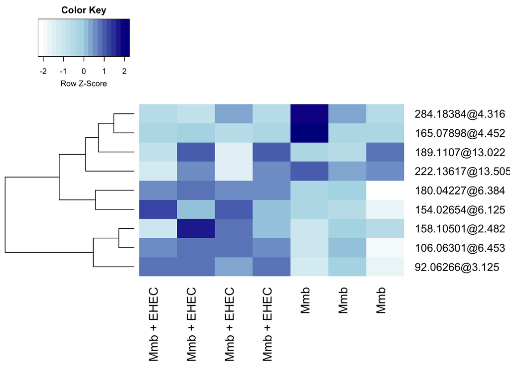

# Human metabolites in infection

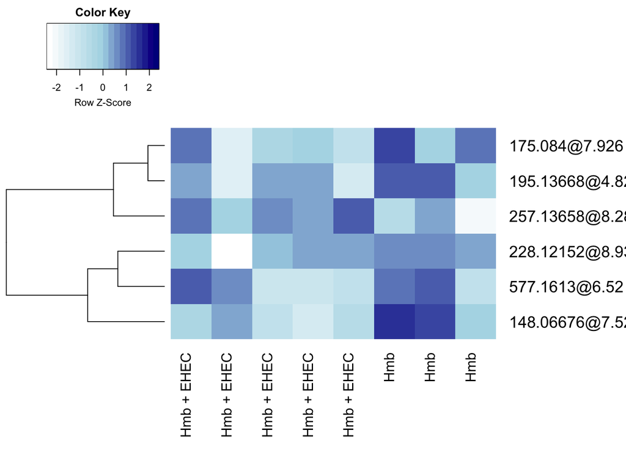

# Future directions

- Analyzing the host side of transcriptomics
- ConDDR for identification for tolerance inducing compounds based on host data
- Metabolite selection for *treatment* of chips